# Deep Neural Auto Encoders

Welcome to this notebook, here we are going to perform a run down analysis on various use-cases based on auto encoders, so hold tight here we go......

An autoencoder network is actually a pair of two connected networks, an encoder and a decoder. An encoder network takes in an input, and converts it into a smaller, dense representation, which the decoder network can use to convert it back to the original input.

## 1. Auto Encoders for Dimensionality Reduction

[figure not shown]

```python
from keras.layers import Input, Dense
from keras.models import Model,Sequential
from keras.layers import Input, Dense, Conv2D, MaxPooling2D, UpSampling2D, Lambda, Layer, Add, Multiply
from keras import backend as K
from keras.losses import mse, binary_crossentropy
from keras.datasets import mnist
from keras.datasets import fashion_mnist
import warnings
import numpy as np
import matplotlib.pyplot as plt
from scipy.stats import norm
import time
#### Import ends


warnings.filterwarnings("ignore")

(x_train, _), (x_test, _) = fashion_mnist.load_data() # download the data set and split it into train and test

# scale the values of pixel between 0 and 1
x_train = x_train.astype('float32') / 255.
x_test = x_test.astype('float32') / 255.

# reshape the 28*28 image into one long vector of size 784
x_train = x_train.reshape((len(x_train), np.prod(x_train.shape[1:])))
x_test = x_test.reshape((len(x_test), np.prod(x_test.shape[1:])))
```

```
Downloading data from http://fashion-mnist.s3-website.eu-central-1.amazonaws.com/train-labels-idx1-ubyte.gz
Downloading data from http://fashion-mnist.s3-website.eu-central-1.amazonaws.com/train-images-idx3-ubyte.gz
Downloading data from http://fashion-mnist.s3-website.eu-central-1.amazonaws.com/t10k-labels-idx1-ubyte.gz
Downloading data from http://fashion-mnist.s3-website.eu-central-1.amazonaws.com/t10k-images-idx3-ubyte.gz
```

```python
print("We have {} training examples and {} test examples".format(x_train.shape[0], x_test.shape[0]))
```

```
We have 60000 training examples and 10000 test examples
```

Lets first have a look at the data set, below is a function that will help us display the images.

```python
 def show_images(data_array,n,decoded_array,title,reconstruct=False,):
    fig=plt.figure(figsize=(20, 4)) # set the layout size
    fig.suptitle(title) # set the plot title
    for i in range(n):
        # display original
        ax = plt.subplot(2, n, i + 1)
        plt.imshow(data_array[i].reshape(28, 28)) # reshape to 28*28 shape and display in subplot
        plt.gray() # grayscale the image
        ax.get_xaxis().set_visible(False) # hide x axis
        ax.get_yaxis().set_visible(False) # hide y axis

        if reconstruct==True: # check if we want to create a dual comparision plot
            ax = plt.subplot(2, n, i + 1 + n)
            plt.imshow(decoded_array[i].reshape(28, 28))
            plt.gray()
            ax.get_xaxis().set_visible(False)
            ax.get_yaxis().set_visible(False)
    plt.show()
```

[figure not shown]

```python
show_images(x_train,10,np.array([1]),'Original Image', False)
```

I have purposely chosen an example of a image datasets as its easy to see the reconstruction of an image as compared to raw data.

Lets begin by creating the model architecture , there are multiple ways you can build up an auto-encoder. You can use any of the following to perform dimensionality reduction:

- simple autoencoder based on a fully-connected layer: Use just one hidden layer(bottleneck)
- sparse autoencoder: Make use of regularisation
- deep fully-connected autoencoder : Build a full scale deep NN
- deep convolutional autoencoder: Use CNN to extract features from your image and build a compressed representation

To fully give you a flavor of how the compression is achieved in auto encoder , I am going to build it using a deep fully-connected autoencoder. The way it works is as follows:

- The encoder is a **Fully Connected Feed Forward NN** , consisting of 2 hidden layer each having 128 and 64 neurons respectively.
- We use **relu** as an activation function entirely across our network , except for the output layer which uses **sigmoid**.
- We then create one bottleneck or the code layer with just **32 neurons**.
- Next comes our decoder which is also **Fully Connected Feed Forward NN** having 2 hidden layer each having 64 and 128 neurons respectively.
- In the last we have our output layer with same no of neurons as in input layer(784).
- The loss function compares the predicted image with the input image and uses **log loss or binary corssentropy**.
- We use **RmsProp** as our numerical optimizer to optimize the above loss function.
- We plan to train the model for 25 epochs, with a batch size of 512.

```python
input_img = Input(shape=(784,)) # specify the size of the single observation
# Set the encoder
encoded = Dense(128, activation='relu')(input_img) # hidden layer 1
encoded = Dense(64, activation='relu')(encoded) # hidden layer 2
encoded = Dense(32, activation='relu')(encoded) # code/ bottleneck layer

# set the decoder
decoded = Dense(64, activation='relu')(encoded) # hidden layer 4
decoded = Dense(128, activation='relu')(decoded) # hidden layer 5
decoded = Dense(784, activation='sigmoid')(decoded) # output layer layer 3


autoencoder = Model(input_img, decoded) # set the input to output flow
autoencoder.summary() # print out the summary
autoencoder.compile(optimizer='rmsprop', loss='binary_crossentropy') # use the optimizer to start the training

start_time = time.time()
autoencoder.fit(x_train,x_train,
                epochs=25,
                batch_size=512,
                shuffle=True,
                validation_data=(x_test, x_test)) # fit to our mnist dataset

print("\n Time elapsed to train the model {} seconds".format(time.time() - start_time))
```

```
_________________________________________________________________
Layer (type)                 Output Shape              Param #
=================================================================
input_1 (InputLayer)         (None, 784)               0
_________________________________________________________________
dense_1 (Dense)              (None, 128)               100480
_________________________________________________________________
dense_2 (Dense)              (None, 64)                8256
_________________________________________________________________
dense_3 (Dense)              (None, 32)                2080
_________________________________________________________________
dense_4 (Dense)              (None, 64)                2112
_________________________________________________________________
dense_5 (Dense)              (None, 128)               8320
_________________________________________________________________
dense_6 (Dense)              (None, 784)               101136
=================================================================
Total params: 222,384
Trainable params: 222,384
Non-trainable params: 0
_________________________________________________________________
Train on 60000 samples, validate on 10000 samples

 Time elapsed to train the model 29.089777946472168 seconds
```

[figure not shown]

```python
decoded_imgs = autoencoder.predict(x_test) # predict the test images by getting the reconstrcution
show_images(x_test,10, decoded_imgs,'Original vs Reconstructed Images' ,True) # plot the original vs reconstructed
```

## 2. AutoEncoders for image denoising

[figure not shown]

One of the fundamental challenges in the field of image processing and computer vision is image denoising, where the underlying goal is to estimate the original image by suppressing noise from a noise-contaminated version of the image.

We will train the autoencoder to map noisy digits images to clean digits images. The aim is that we need a model to learn how to remove any noise from the data , such the an effectively trained model can be used for performing task like denosing sound signal, or denoising image data etc...

First we start by taking our original image data and add some gaussian noise.

```python
(x_train, _), (x_test, _) = mnist.load_data() # download the data set and split it into train and test

# scale the values of pixel between 0 and 1
x_train = x_train.astype('float32') / 255.
x_test = x_test.astype('float32') / 255.

# reshape the 28*28 image into one long vector of size 784
x_train = x_train.reshape((len(x_train), np.prod(x_train.shape[1:])))
x_test = x_test.reshape((len(x_test), np.prod(x_test.shape[1:])))



x_train_new = np.reshape(x_train, (len(x_train), 28, 28, 1)) # set the channel first format
x_test_new = np.reshape(x_test, (len(x_test), 28, 28, 1))  # set the channel first format

noise_factor = 0.4 # set the amount of noise
x_train_noisy = x_train_new + noise_factor * np.random.normal(loc=0.0, scale=1.0, size=x_train_new.shape) # create noised dataset
x_test_noisy = x_test_new + noise_factor * np.random.normal(loc=0.0, scale=1.0, size=x_test_new.shape)

x_train_noisy = np.clip(x_train_noisy, 0., 1.) # scale the pixels between 0 and 1
x_test_noisy = np.clip(x_test_noisy, 0., 1.)
```

So here is our original data.

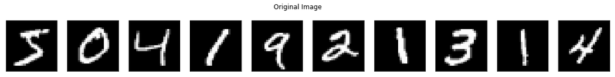

```python
show_images(x_train_new,10,np.array([1]),'Original Image',False)
```

And here is our noisy data

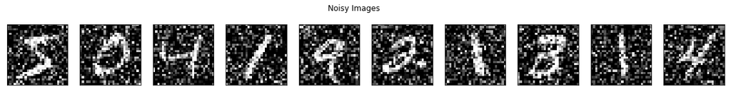

```python
show_images(x_train_noisy,10,np.array([1]),"Noisy Images", False)
```

In this use-case we will make use of the convolution auto encoders that will help us understand both the working of CNN as autoencoder and the way we can design it in a way to perform denosing.

The input to the network will be a noised version of the image and we instruct the network to learn to remove noise by minimising the error between the predicted and denoised image , thus the trained model can be use to effectively remove noise.

The architecture that i have use to construct this is as follows:

- We design the encoder part using **2 CNN + MaxPooling layer** , in each of the 2 layer we use **32 filters of size 3*3 size**.
- We use **relu** as an activation function entirely across our network , except for the output layer which uses **sigmoid**.
- Since we are using a CNN we are going to keep the padding scheme to be 'same' which means we are going to add zero padding across the activations so that the size of the activations does not get shrink as we pass it through the CNN.
- The **MaxPooling will act as a regularisation scheme** helping to reduce the height and width of the activations.
- The encoder will shrink the activation to a shape of **7,7,32**
- We then design the decoder by using **2 CNN+ UpSampling layer** in each of the 2 layer we use **32 filters of size 3*3 size**.
- While decoding we want the image height and width to increase and the channels to decrease and hence we use the **UpSampling** techniques to achieve this.
- The loss function compared the predicted image with the denoised image and uses **log loss or binary crossentropy**.
- We use **RmsProp** as our numerical optimizer to optimize the above loss function.
- We plan to train the model for 25 epochs, with a batch size of 128.

The UpSampling operation repeats the rows and columns of the data by size[0] and size[1] respectively.

```python
input_img = Input(shape=(28, 28, 1))  # adapt this if using `channels_first` image data format

x = Conv2D(32, (3, 3), activation='relu', padding='same')(input_img) # perform convolution operation with 32 filters, hidden layer 1
x = MaxPooling2D((2, 2), padding='same')(x) # use max pololing, hidden layer 1
x = Conv2D(32, (3, 3), activation='relu', padding='same')(x)# hidden layer 2
encoded = MaxPooling2D((2, 2), padding='same')(x) # hidden layer 2

# at this point the representation is (7, 7, 32)

x = Conv2D(32, (3, 3), activation='relu', padding='same')(encoded) # hidden layer 3
x = UpSampling2D((2, 2))(x) # hidden layer 3
x = Conv2D(32, (3, 3), activation='relu', padding='same')(x) # hidden layer 4
x = UpSampling2D((2, 2))(x) # hidden layer 4
decoded = Conv2D(1, (3, 3), activation='sigmoid', padding='same')(x) #hidden layer 5

denoiser = Model(input_img, decoded) # set up the data flow
denoiser.summary() # print the model summary
denoiser.compile(optimizer='rmsprop', loss='binary_crossentropy') # run through the optimizer

start_time = time.time()

denoiser.fit(x_train_noisy, x_train_new,
                epochs=25,
                batch_size=128,
                shuffle=True,
                validation_data=(x_test_noisy, x_test_new)) # pass the data

print("\n Time elapsed to train the model {} seconds".format(time.time() - start_time))
```

```
_________________________________________________________________
Layer (type)                 Output Shape              Param #
=================================================================
input_3 (InputLayer)         (None, 28, 28, 1)         0
_________________________________________________________________
conv2d_6 (Conv2D)            (None, 28, 28, 32)        320
_________________________________________________________________
max_pooling2d_3 (MaxPooling2 (None, 14, 14, 32)        0
_________________________________________________________________
conv2d_7 (Conv2D)            (None, 14, 14, 32)        9248
_________________________________________________________________
max_pooling2d_4 (MaxPooling2 (None, 7, 7, 32)          0
_________________________________________________________________
conv2d_8 (Conv2D)            (None, 7, 7, 32)          9248
_________________________________________________________________
up_sampling2d_3 (UpSampling2 (None, 14, 14, 32)        0
_________________________________________________________________
conv2d_9 (Conv2D)            (None, 14, 14, 32)        9248
_________________________________________________________________
up_sampling2d_4 (UpSampling2 (None, 28, 28, 32)        0
_________________________________________________________________
conv2d_10 (Conv2D)           (None, 28, 28, 1)         289
=================================================================
Total params: 28,353
Trainable params: 28,353
Non-trainable params: 0
_________________________________________________________________
Train on 60000 samples, validate on 10000 samples

 Time elapsed to train the model 159.6751983165741 seconds
```

So our model is trained lets have a look at how the model behaves when we pass in the noisy images.

Below is the noised image

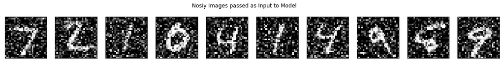

```python
show_images(x_test_noisy,10,np.array([1]),"Nosiy Images passed as Input to Model" ,False)
```

Below is the denoised image

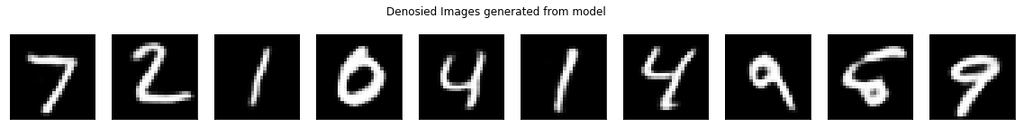

```python
denoised_imgs = denoiser.predict(x_test_noisy) # get the predicted image
show_images(denoised_imgs,10, np.array([1]), 'Denosied Images generated from model',False) # plot the predicted images
```

The results are pretty impressive ,we can clearly see that the trained model is in the position of removing the noise in the dataset.

# 3. Varational AutoEncoder for generating new MNIST images

[figure not shown]

Variational Autoencoders (VAEs) are powerful generative models, now having applications as diverse as from generating fake human faces, to producing purely synthetic music.

Variational Autoencoders (VAEs) have one fundamentally unique property that separates them from vanilla autoencoders, and it is this property that makes them so useful for generative modeling: their latent spaces are, by design, continuous, allowing easy random sampling and interpolation.

It achieves this by doing something that seems rather surprising at first: making its encoder not output an encoding vector of size n, rather, outputting two vectors of size n: a vector of means, μ, and another vector of standard deviations, σ.

The architecture that i have use to construct this is as follows:

- **Encoder :-** 1 input layer + 1 Feed Forward layer with 256 neurons
- **Activation Function :-** Relu + Sigmoid
- **Code Layer Size :-** 2 layers with 2 neurons one for each mean and std
- **Decoder :-** 1 Feed Forward layer with 256 neurons + 1 output layer
- **Loss Function :-** Binary crossentropy
- **Optimizer :-** RmsProp
- **Epochs :-** 100
- **Batch Size :-** 512

```python
original_dim = 784
intermediate_dim = 256
latent_dim = 2
batch_size = 512
epochs = 100
epsilon_std = 1.0


def nll(y_true, y_pred):
    return K.sum(K.binary_crossentropy(y_true, y_pred), axis=-1) # use negative log likelihood


class KLDivergenceLayer(Layer):
    def __init__(self, *args, **kwargs):
        self.is_placeholder = True
        super(KLDivergenceLayer, self).__init__(*args, **kwargs)

    def call(self, inputs):
        mu, log_var = inputs
        kl_batch = - .5 * K.sum(1 + log_var -
                                K.square(mu) -
                                K.exp(log_var), axis=-1)
        self.add_loss(K.mean(kl_batch), inputs=inputs) # add kl divergence to the loss
        return inputs
```

```python
decoder = Sequential([
    Dense(intermediate_dim, input_dim=latent_dim, activation='relu'),
    Dense(original_dim, activation='sigmoid')
]) # set the decoder network to have 2 dense layer

x = Input(shape=(original_dim,)) # set the input layer
h = Dense(intermediate_dim, activation='relu')(x) # set the 1st hidden layer

z_mu = Dense(latent_dim)(h) # create a code layer to learn the mean of data
z_log_var = Dense(latent_dim)(h) # create a code layer to learn the std of data

z_mu, z_log_var = KLDivergenceLayer()([z_mu, z_log_var])
z_sigma = Lambda(lambda t: K.exp(.5*t))(z_log_var)

eps = Input(tensor=K.random_normal(stddev=epsilon_std,
                                   shape=(K.shape(x)[0], latent_dim)))
z_eps = Multiply()([z_sigma, eps])
z = Add()([z_mu, z_eps])

x_pred = decoder(z)

vae = Model(inputs=[x, eps], outputs=x_pred) # set the data flow in model
vae.compile(optimizer='rmsprop', loss=nll) # complie the network
vae.summary() # print out the summary

(x_train, y_train), (x_test, y_test) = mnist.load_data() # load the dataset
x_train = x_train.reshape(-1, original_dim) / 255. # scale it between 0 and 1
x_test = x_test.reshape(-1, original_dim) / 255.

start_time = time.time()

vae.fit(x_train,
        x_train,
        shuffle=True,
        epochs=epochs,
        batch_size=batch_size,
        validation_data=(x_test, x_test))
print("\n Time elapsed to train the model {} seconds".format(time.time() - start_time))
```

```
__________________________________________________________________________________________________
Layer (type)                    Output Shape         Param #     Connected to
==================================================================================================
input_4 (InputLayer)            (None, 784)          0
__________________________________________________________________________________________________
dense_9 (Dense)                 (None, 256)          200960      input_4[0][0]
__________________________________________________________________________________________________
dense_10 (Dense)                (None, 2)            514         dense_9[0][0]
__________________________________________________________________________________________________
dense_11 (Dense)                (None, 2)            514         dense_9[0][0]
__________________________________________________________________________________________________
kl_divergence_layer_1 (KLDiverg [(None, 2), (None, 2 0           dense_10[0][0]
                                                                 dense_11[0][0]
__________________________________________________________________________________________________
lambda_1 (Lambda)               (None, 2)            0           kl_divergence_layer_1[0][1]
__________________________________________________________________________________________________
input_5 (InputLayer)            (None, 2)            0
__________________________________________________________________________________________________
multiply_1 (Multiply)           (None, 2)            0           lambda_1[0][0]
                                                                 input_5[0][0]
__________________________________________________________________________________________________
add_1 (Add)                     (None, 2)            0           kl_divergence_layer_1[0][0]
                                                                 multiply_1[0][0]
__________________________________________________________________________________________________
sequential_1 (Sequential)       (None, 784)          202256      add_1[0][0]
==================================================================================================
Total params: 404,244
Trainable params: 404,244
Non-trainable params: 0
__________________________________________________________________________________________________
Train on 60000 samples, validate on 10000 samples

 Time elapsed to train the model 135.9676914215088 seconds
```

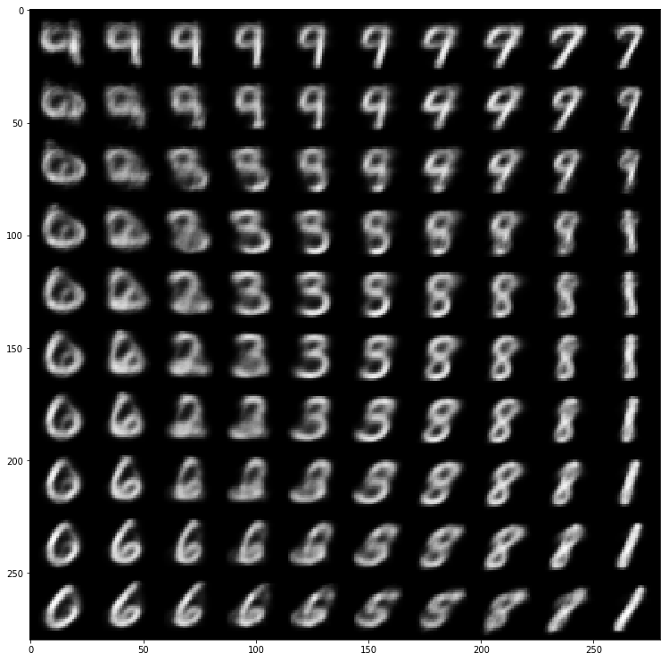

```python
# display a 2D manifold of the digits
n = 10  # figure with 15x15 digits
digit_size = 28
u_grid = np.dstack(np.meshgrid(np.linspace(0.05, 0.95, n),
                               np.linspace(0.05, 0.95, n)))
z_grid = norm.ppf(u_grid)
x_decoded_n = decoder.predict(z_grid.reshape(n*n, 2))
x_decoded_w = x_decoded_n.reshape(n, n, digit_size, digit_size)

plt.figure(figsize=(13, 13))
plt.imshow(np.block(list(map(list, x_decoded_w))), cmap='gray')
plt.show()
```

In this notebook we saw the various application and architectures of Auto Encoders and by this time you would have got an idea about how useful this network can be. With the robustness and versatility this network brings i am sure it would inspire you all to give it a try and see it for yourself how useful it can be.

Once again thanks for going though this notebook.

[figure not shown]